# Caso Especial Comparar Regresión Lineal Simple VS Regresión Polinomial con datos de Advertising

Luis Alberto Jimenez Soto

2022-09-20

# 1 Objetivo

Evaluar y comparar los modelos de regresión lineal simple y polinomial de segunda y quinta pontecia con datos de Adverstising_WEB.csv

# 2 Descripción

Se cargan los datos de la dirección:https://raw.githubusercontent.com/rpizarrog/Analisis-Inteligente-de-datos/main/datos/Advertising_Web.csv

Los datos contienen variables que en el contexto se interpreta que son inversiones hechas de una empresa y las ventas de la misma, a tanta inversión de marketing en medios tales como TV, Radio, *NewsPapers* (medios impresos) y *Web* (digital) existe en relacuón a las ventas (*Sales*) generadas.

Se trata de comparar modelos predictivos para evaluar cuál es mejor con respecto a los estadísticos *R Square* y *RMSE*.

Las variables de interés serán:

- **TV** como variable independiente o la variable explicativa hacia la variables *Sales*
- **Sales** como variable dependiente que es la variable a predecir.
- Se construyen datos de entrenamiento y datos de validacion al 70 y 30% respectivamente

Se construyen el modelo de regresión lineal simple con los datos de entrenamiento y se evaluán los siguiente aspectos:

- Se identifican los coeficientes a y b
- Se analizan los niveles de confianza de los coeficientes.
- Se identifica el valor de *R Square* par evaluar el grado de explicación de la variable dependiente con respecto a la variable independiente. El modelo **se acepta si está por encima del 60%.**
- Se hacen prediciones con la funcion *predict()* con los datos de validación.
- Se mide el valor de *RMSE Root Mean Stándar Error.*

Se construye el modelo polinomial a la segunda potencia y quinta potencia con los datos de entrenamiento y se evalúan los siguientes aspectos.

- Se identifican los coeficientes
- Se analizan los niveles de confianza de los coeficientes.
- Se identifica el valor de *R Square* para evaluar el grado de explicación de la variable independiente con respecto a la variable dependiente. **Se acepta si está por encima del 60%**
- Se hacen prediciones con la funcion *predict()* con los datos de validación.
- Se mide el valor de *rmse Root Mean Stándar Error.*

# 3 Desarrollo

## 3.1 Cargar librerías

```r
library(readr)   # Sirve para importar datos
library(Metrics) # Sirve para construir métricas y valorar modelos
library (ggplot2) # Sirve para gráficos
library(caret)    # Para partir los datos Entrenamiento y Validación.
library(knitr)
```

## 3.2 Cargar datos

```r
datos <- read.csv("https://raw.githubusercontent.com/rpizarrog/Analisis-Inteligente-de-datos/main/datos/Advertising_Web.csv")
```

## 3.3 Describir datos

```r
summary(datos)
```

```
##       X.1               X                TV             Radio
##  Min.   :  1.00   Min.   :  1.00   Min.   :  0.70   Min.   : 0.000
##  1st Qu.: 50.75   1st Qu.: 50.75   1st Qu.: 74.38   1st Qu.: 9.975
##  Median :100.50   Median :100.50   Median :149.75   Median :22.900
##  Mean   :100.50   Mean   :100.50   Mean   :147.04   Mean   :23.264
##  3rd Qu.:150.25   3rd Qu.:150.25   3rd Qu.:218.82   3rd Qu.:36.525
##  Max.   :200.00   Max.   :200.00   Max.   :296.40   Max.   :49.600
##    Newspaper           Web              Sales
##  Min.   :  0.30   Min.   :  4.308   Min.   : 1.60
##  1st Qu.: 12.75   1st Qu.: 99.049   1st Qu.:10.38
##  Median : 25.75   Median :156.862   Median :12.90
##  Mean   : 30.55   Mean   :159.587   Mean   :14.02
##  3rd Qu.: 45.10   3rd Qu.:212.312   3rd Qu.:17.40
##  Max.   :114.00   Max.   :358.247   Max.   :27.00
```

```r
str(datos)
```

```
## 'data.frame':    200 obs. of  7 variables:
##  $ X.1      : int  1 2 3 4 5 6 7 8 9 10 ...
##  $ X        : int  1 2 3 4 5 6 7 8 9 10 ...
##  $ TV       : num  230.1 44.5 17.2 151.5 180.8 ...
##  $ Radio    : num  37.8 39.3 45.9 41.3 10.8 48.9 32.8 19.6 2.1 2.6 ...
##  $ Newspaper: num  69.2 45.1 69.3 58.5 58.4 75 23.5 11.6 1 21.2 ...
##  $ Web      : num  306.6 302.7 49.5 257.8 195.7 ...
##  $ Sales    : num  22.1 10.4 9.3 18.5 12.9 7.2 11.8 13.2 4.8 10.6 ...
```

### 3.3.1 Visualizar la dispersión de los datos

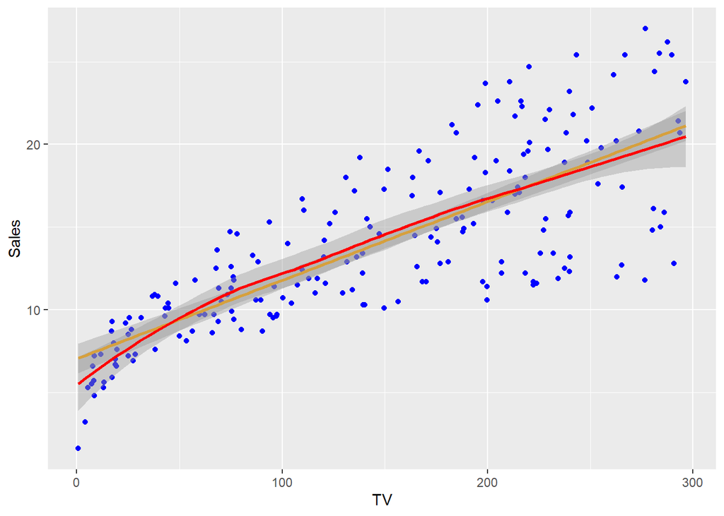

```r
ggplot(datos, aes(x = TV, y = Sales)) +
  geom_point(colour = "blue") +
  geom_smooth(colour = 'orange', method = lm) +
  geom_smooth(colour = 'red')
```

Se observa que la relación entre las dos variables no es del todo lineal.

## 3.4 Construir Datos de entrenamiento y validación

Los datos de entrenamiento son el 70% de los datos originales y los de validación el 30%.

```r
set.seed(1271)
```

Los datos se particionan usando la función *createDataPartition()* al 70 % el resultado es vector con los registros que pertenecen a datos de entrenamiento de los datos originales.

- *datos[entrena, ]*, son los datos de entrenamiento y
- *datos[- entrena, ]* son los datos de validación.

```r
entrena <- createDataPartition(y = datos$Sales, p = 0.70, list = FALSE, times = 1)
# Datos entrenamiento
datos.entrenamiento <- datos[entrena, ]  # [renglones, columna]
# Datos validación
datos.validacion <- datos[-entrena, ]
```

### 3.4.1 Datos de entrenamiento 70%

Se despliegan los primeros diez registros de los datos de entrenamiento y no deben aparecer en los datos de validación deben ser diferentes unos con otros.

```r
head(datos.entrenamiento, 10)
```

```
##    X.1  X    TV Radio Newspaper       Web Sales
## 2    2  2  44.5  39.3      45.1 302.65307  10.4
## 3    3  3  17.2  45.9      69.3  49.49891   9.3
## 4    4  4 151.5  41.3      58.5 257.81689  18.5
## 5    5  5 180.8  10.8      58.4 195.66008  12.9
## 6    6  6   8.7  48.9      75.0  22.07240   7.2
## 8    8  8 120.2  19.6      11.6 229.97146  13.2
## 9    9  9   8.6   2.1       1.0 144.61739   4.8
## 11  11 11  66.1   5.8      24.2  45.35903   8.6
## 12  12 12 214.7  24.0       4.0 164.97176  17.4
## 13  13 13  23.8  35.1      65.9  87.92109   9.2
```

```r
paste("Número de observaciones en datos de entrenamiento ", nrow(datos.entrenamiento))
```

```
## [1] "Número de observaciones en datos de entrenamiento  142"
```

### 3.4.2 Datos de validación 30%

Se despliegan los primeros diez registros y no deben estar en los datos de entrenamiento

```r
head(datos.validacion, 10)
```

```
##    X.1  X    TV Radio Newspaper       Web Sales
## 1    1  1 230.1  37.8      69.2 306.63475  22.1
## 7    7  7  57.5  32.8      23.5 246.81160  11.8
## 10  10 10 199.8   2.6      21.2 111.27226  10.6
## 16  16 16 195.4  47.7      52.9 148.09513  22.4
## 17  17 17  67.8  36.6     114.0 202.63890  12.5
## 19  19 19  69.2  20.5      18.3 210.48991  11.3
## 20  20 20 147.3  23.9      19.1 268.73538  14.6
## 23  23 23  13.2  15.9      49.6 219.88278   5.6
## 37  37 37 266.9  43.8       5.0  96.31683  25.4
## 39  39 39  43.1  26.7      35.1 122.75359  10.1
```

```r
paste("Número de observaciones en datos de entrenamiento ", nrow(datos.validacion))
```

```
## [1] "Número de observaciones en datos de entrenamiento  58"
```

## 3.5 Modelo de regresión lineal simple

La variable dependiente *Sales* está en función de la variable independiente *TV* y se designa con el argumento *Formula = Sales ~ TV* de los datos (*data*) de entrenamiento.

```r
modelo.simple <- lm(data = datos.entrenamiento, formula = Sales ~ TV)
```

### 3.5.1 Resumen del modelo

Generando el resumen del modelo

```r
resumen <- summary(modelo.simple)
resumen
```

```
##
## Call:
## lm(formula = Sales ~ TV, data = datos.entrenamiento)
##
## Residuals:
##    Min     1Q Median     3Q    Max
## -7.922 -2.022 -0.199  2.107  7.516
##
## Coefficients:
##             Estimate Std. Error t value Pr(>|t|)
## (Intercept) 7.269492   0.553258   13.14   <2e-16 ***
## TV          0.045004   0.003189   14.11   <2e-16 ***
## ---
## Signif. codes:  0 '***' 0.001 '**' 0.01 '*' 0.05 '.' 0.1 ' ' 1
##
## Residual standard error: 3.266 on 140 degrees of freedom
## Multiple R-squared:  0.5872, Adjusted R-squared:  0.5843
## F-statistic: 199.2 on 1 and 140 DF,  p-value: < 2.2e-16
```

### 3.5.2 El valor de los coeficientes a y b

```r
a <- modelo.simple$coefficients[1]
b <- modelo.simple$coefficients[2]
a; b
```

```
## (Intercept)
##    7.269492
```

```
##         TV
## 0.04500449
```

Los coeficientes tienen un nivel de confianza a 99% (‘***’) por lo que el modelo tiene buenos predictores o al 99% de confianza.

### 3.5.3 Valor de R Square

```r
resumen$r.squared
```

```
## [1] 0.5872492
```

### 3.5.4 Predicciones del modelo

Con la función *predict()* se generan predicciones de los datos de validación.

Las predicciones estarán en función de la fórmula y de los valores de los coeficentes a y b:

```r
predicciones <- predict(object = modelo.simple, newdata = datos.validacion)
```

#### 3.5.4.1 Estimación lineal

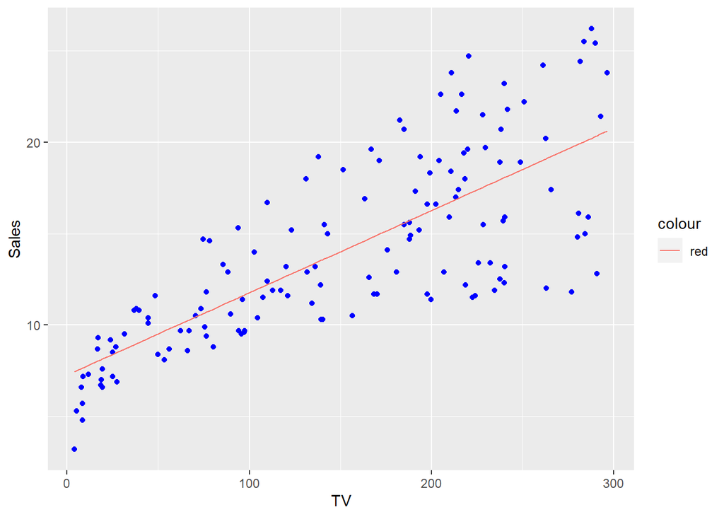

```r
ggplot(data = datos.entrenamiento, aes(x = TV, y = Sales)) +
  geom_point(colour = "blue") +
  geom_line(aes(x = TV, y = modelo.simple$fitted.values, colour = 'red'))
```

#### 3.5.4.2 Generar tabla comparativa

Se construye una tabla comparativa con los datos de validación y las predicciones generadas para comparar y generar el estadístico *rmse*.

```r
tabla <- data.frame(TV = datos.validacion$TV, Sales.real = datos.validacion$Sales, Sales.predicciones = predicciones)
tabla
```

```
##        TV Sales.real Sales.predicciones
## 1   230.1       22.1          17.625026
## 7    57.5       11.8           9.857250
## 10  199.8       10.6          16.261390
## 16  195.4       22.4          16.063370
## 17   67.8       12.5          10.320797
## 19   69.2       11.3          10.383803
## 20  147.3       14.6          13.898654
## 23   13.2        5.6           7.863551
## 37  266.9       25.4          19.281191
## 39   43.1       10.1           9.209186
## 42  177.0       17.1          15.235287
## 43  293.6       20.7          20.482811
## 46  175.1       14.9          15.149779
## 49  227.2       14.8          17.494513
```

[output cut: 44 more lines]

#### 3.5.4.3 Evaluar predicciones con *rmse*

Se determina la variación de los valores reales contra las predicciones por medio del estadístico *rmse (Root Mean Stándar Error)* que servirá para compararse con otro modelo concluyendo que en el que tenga menor error es mas eficiente el modelo.

*rmse* Root Mean Stándar Error, este valor normalmente se compara contra otro modelo y el que esté mas cerca de cero es mejor.

*RMSE* es una forma útil de ver qué tan bien un modelo de regresión puede ajustarse a un conjunto de datos.

Cuanto mayor sea el *rmse*, mayor será la diferencia entre los valores predichos y reales, lo que significa que peor se ajusta un modelo de regresión a los datos. Por el contrario, cuanto más pequeño sea el rmse, mejor podrá un modelo ajustar los datos.

$$rmse = \sqrt{\frac{\sum(predicho_i - real_i)^{2}}{n}}$$

Se obtiene la métrica con la función *rmse*() de la librería *Metrics* previamente argada.

```r
rmse.lineal <- rmse(actual = tabla$Sales.real, predicted = tabla$Sales.predicciones)
rmse.lineal
```

```
## [1] 3.274451
```

El valor de *rmse* es de: 3.2744511 y habrá que compararse con otro modelo que se haya construído con los mismos datos y las mismas variables, ejemplo modelos de regresión polinomial.

## 3.6 Modelo de regresión polinomial de segundo nivel

La variable dependiente *Sales* está en función de la variable independiente *TV* y se designa con el argumento *Formula = Sales ~ TV* de los datos (*data*) de entrenamiento pero en función de elevar al cuadrado el valor del coeficiente TV.

$$Y = \beta0 + \beta_1\cdot x_i+\beta_2\cdot x_i^2 + ... \beta_n \cdot
x_i^n$$

### 3.6.1 Usando argumento Poly

```r
modelo.poly2 <- lm(data = datos.entrenamiento, formula = Sales ~ poly(x = TV, degree = 2, raw = TRUE))
```

### 3.6.2 Usando argumento I

```r
modelo.poly2.I <- lm(Sales ~ TV + I(x = TV ^ 2), data = datos.entrenamiento)
```

### 3.6.3 Resumen del modelo

Generando el resumen del modelo

```r
resumen <- summary(modelo.poly2)
resumen
```

```
##
## Call:
## lm(formula = Sales ~ poly(x = TV, degree = 2, raw = TRUE), data = datos.entrenamiento)
##
## Residuals:
##     Min      1Q  Median      3Q     Max
## -7.2387 -2.0754 -0.2335  1.9948  7.3935
##
## Coefficients:
##                                         Estimate Std. Error t value Pr(>|t|)
## (Intercept)                            6.326e+00  7.943e-01   7.965 5.34e-13
## poly(x = TV, degree = 2, raw = TRUE)1  6.507e-02  1.260e-02   5.166 8.14e-07
## poly(x = TV, degree = 2, raw = TRUE)2 -6.913e-05  4.200e-05  -1.646    0.102
##
## (Intercept)                           ***
## poly(x = TV, degree = 2, raw = TRUE)1 ***
## poly(x = TV, degree = 2, raw = TRUE)2
## ---
## Signif. codes:  0 '***' 0.001 '**' 0.01 '*' 0.05 '.' 0.1 ' ' 1
##
## Residual standard error: 3.247 on 139 degrees of freedom
## Multiple R-squared:  0.5951, Adjusted R-squared:  0.5893
## F-statistic: 102.2 on 2 and 139 DF,  p-value: < 2.2e-16
```

Los coeficientes tienen un nivel de confianza a 99% (‘***’) excepto el predictor b2 que tienen un nivel de confianza por debajo del 90%. Sin embargo se aceptan los predictores.

### 3.6.4 El valor de los coeficientes con modelo Poly

```r
b0 <- modelo.poly2$coefficients[1]
b1 <- modelo.poly2$coefficients[2]
b2 <- modelo.poly2$coefficients[3]
b0; b1; b2
```

```
## (Intercept)
##    6.326107
```

```
## poly(x = TV, degree = 2, raw = TRUE)1
##                            0.06507278
```

```
## poly(x = TV, degree = 2, raw = TRUE)2
##                         -6.913325e-05
```

### 3.6.5 Coeficientes con el modelo I

```r
bI0 <- modelo.poly2$coefficients[1]
bI1 <- modelo.poly2$coefficients[2]
bI2 <- modelo.poly2$coefficients[3]
bI0; bI1; bI2
```

```
## (Intercept)
##    6.326107
```

```
## poly(x = TV, degree = 2, raw = TRUE)1
##                            0.06507278
```

```
## poly(x = TV, degree = 2, raw = TRUE)2
##                         -6.913325e-05
```

Deben ser los mismos valores.

### 3.6.6 Valor de R Square

```r
resumen$r.squared
```

```
## [1] 0.5951414
```

### 3.6.7 Predicciones del modelo

Con la función *predict()* se generan predicciones de los datos de validación.

Las predicciones estarán en función de la fórmula y de los valores de los coeficentes a y b:

```r
predicciones <- predict(object = modelo.poly2, newdata = datos.validacion)
```

#### 3.6.7.1 Curva de estimación

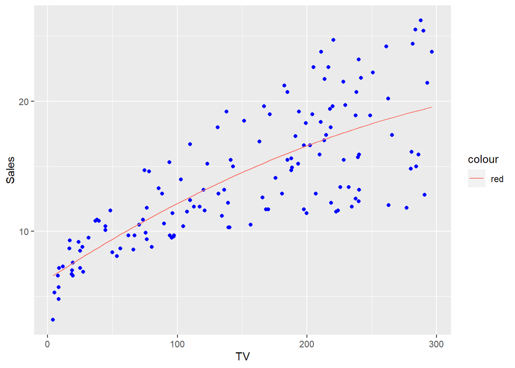

```r
ggplot(data = datos.entrenamiento, aes(x = TV, y = Sales)) +
  geom_point(colour = "blue") +
  geom_line(aes(x = TV, y = modelo.poly2$fitted.values, colour = 'red'))
```

#### 3.6.7.2 Generar tabla comparativa

Se construye una tabla comparativa con los datos de validación y las predicciones generadas para comparar y generar el estadístico *rmse*.

```r
tabla <- data.frame(TV = datos.validacion$TV, Sales.real = datos.validacion$Sales, Sales.predicciones = predicciones)
tabla
```

```
##        TV Sales.real Sales.predicciones
## 1   230.1       22.1          17.639025
## 7    57.5       11.8           9.839220
## 10  199.8       10.6          16.567847
## 16  195.4       22.4          16.401741
## 17   67.8       12.5          10.420247
## 19   69.2       11.3          10.498089
## 20  147.3       14.6          14.411324
## 23   13.2        5.6           7.173022
## 37  266.9       25.4          18.769284
## 39   43.1       10.1           9.002321
## 42  177.0       17.1          15.678114
## 43  293.6       20.7          19.472124
## 46  175.1       14.9          15.600725
## 49  227.2       14.8          17.541996
```

[output cut: 44 more lines]

#### 3.6.7.3 Evaluar predicciones con *rmse*

Se determina la variación de los valores reales contra las predicciones por medio del estadístico *rmse (Root Mean Stándar Error)* que servirá para compararse con otro modelo concluyendo que en el que tenga menor error es mas eficiente el modelo.

*rmse* Root Mean Stándar Error, este valor normalmente se compara contra otro modelo y el que esté mas cerca de cero es mejor.

*RMSE* es una forma útil de ver qué tan bien un modelo de regresión puede ajustarse a un conjunto de datos.

Cuanto mayor sea el *rmse*, mayor será la diferencia entre los valores predichos y reales, lo que significa que peor se ajusta un modelo de regresión a los datos. Por el contrario, cuanto más pequeño sea el rmse, mejor podrá un modelo ajustar los datos.

$$rmse = \sqrt{\frac{\sum(predicho_i - real_i)^{2}}{n}}$$

Se obtiene la métrica con la función *rmse*() de la librería *Metrics* previamente argada.

```r
rmse.poly2 <- rmse(actual = tabla$Sales.real, predicted = tabla$Sales.predicciones)
rmse.poly2
```

```
## [1] 3.243766
```

El valor de *rmse* es de: 3.2437655 y habrá que compararse con otro modelo que se haya construido con los mismos datos y las mismas variables, ejemplo modelos de regresión polinomial.

## 3.7 Modelo de regresión polinomial de quinto nivel

La variable dependiente *Sales* está en función de la variable independiente *TV* y se designa con el argumento *Formula = Sales ~ TV* de los datos (*data*) de entrenamiento pero en función de elevar a la quinta potencia el valor del coeficiente TV.

$$Y = \beta0 + \beta_1\cdot x_i+\beta_2\cdot x_i^2 + ... \beta_5\cdot
x_i^5$$

### 3.7.1 Usando argumento Poly

```r
modelo.poly5 <- lm(data = datos.entrenamiento, formula = Sales ~ poly(x = TV, degree = 5, raw = TRUE))
```

### 3.7.2 Resumen del modelo

Generando el resumen del modelo

```r
resumen <- summary(modelo.poly5)
resumen
```

```
##
## Call:
## lm(formula = Sales ~ poly(x = TV, degree = 5, raw = TRUE), data = datos.entrenamiento)
##
## Residuals:
##     Min      1Q  Median      3Q     Max
## -7.7186 -1.8303 -0.1965  1.9391  7.4632
##
## Coefficients:
##                                         Estimate Std. Error t value Pr(>|t|)
## (Intercept)                            3.714e+00  1.755e+00   2.115   0.0362 *
## poly(x = TV, degree = 5, raw = TRUE)1  2.906e-01  1.251e-01   2.322   0.0217 *
## poly(x = TV, degree = 5, raw = TRUE)2 -4.987e-03  2.584e-03  -1.930   0.0557 .
## poly(x = TV, degree = 5, raw = TRUE)3  4.270e-05  2.182e-05   1.957   0.0524 .
## poly(x = TV, degree = 5, raw = TRUE)4 -1.599e-07  8.053e-08  -1.986   0.0490 *
## poly(x = TV, degree = 5, raw = TRUE)5  2.153e-10  1.076e-10   2.001   0.0474 *
## ---
## Signif. codes:  0 '***' 0.001 '**' 0.01 '*' 0.05 '.' 0.1 ' ' 1
##
## Residual standard error: 3.23 on 136 degrees of freedom
## Multiple R-squared:  0.6079, Adjusted R-squared:  0.5935
## F-statistic: 42.18 on 5 and 136 DF,  p-value: < 2.2e-16
```

### 3.7.3 El valor de los coeficientes con modelo Poly

```r
b0 <- modelo.poly5$coefficients[1]
b1 <- modelo.poly5$coefficients[2]
b2 <- modelo.poly5$coefficients[3]
b3 <- modelo.poly5$coefficients[4]
b4 <- modelo.poly5$coefficients[5]
b5 <- modelo.poly5$coefficients[6]
b0; b1; b2; b3; b4; b5
```

```
## (Intercept)
##    3.713603
```

```
## poly(x = TV, degree = 5, raw = TRUE)1
##                             0.2905507
```

```
## poly(x = TV, degree = 5, raw = TRUE)2
##                          -0.004987459
```

```
## poly(x = TV, degree = 5, raw = TRUE)3
##                           4.27025e-05
```

```
## poly(x = TV, degree = 5, raw = TRUE)4
##                         -1.599296e-07
```

```
## poly(x = TV, degree = 5, raw = TRUE)5
##                          2.152689e-10
```

### 3.7.4 Valor de R Square

```r
resumen$r.squared
```

```
## [1] 0.6079402
```

### 3.7.5 Predicciones del modelo

Con la función *predict()* se generan predicciones de los datos de validación.

Las predicciones estarán en función de la fórmula y de los valores de los coeficentes a y b:

```r
predicciones <- predict(object = modelo.poly5, newdata = datos.validacion)
```

#### 3.7.5.1 Curva de estimación

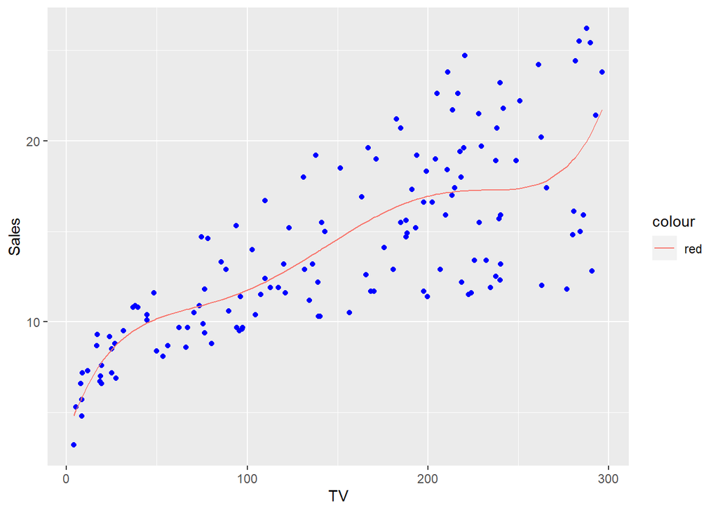

```r
ggplot(data = datos.entrenamiento, aes(x = TV, y = Sales)) +
  geom_point(colour = "blue") +
  geom_line(aes(x = TV, y = modelo.poly5$fitted.values, colour = 'red'))
```

#### 3.7.5.2 Generar tabla comparativa

Se construye una tabla comparativa con los datos de validación y las predicciones generadas para comparar y generar el estadístico *rmse*.

```r
tabla <- data.frame(TV = datos.validacion$TV, Sales.real = datos.validacion$Sales, Sales.predicciones = predicciones)
tabla
```

```
##        TV Sales.real Sales.predicciones
## 1   230.1       22.1          17.271097
## 7    57.5       11.8          10.435699
## 10  199.8       10.6          16.939235
## 16  195.4       22.4          16.821237
## 17   67.8       12.5          10.724246
## 19   69.2       11.3          10.761299
## 20  147.3       14.6          14.412376
## 23   13.2        5.6           6.773302
## 37  266.9       25.4          17.863189
## 39   43.1       10.1           9.870619
## 42  177.0       17.1          16.110347
## 43  293.6       20.7          21.098658
## 46  175.1       14.9          16.018497
## 49  227.2       14.8          17.264931
```

[output cut: 44 more lines]

#### 3.7.5.3 Evaluar predicciones con *rmse*

Se determina la variación de los valores reales contra las predicciones por medio del estadístico *rmse (Root Mean Stándar Error)* que servirá para compararse con otro modelo concluyendo que en el que tenga menor error es mas eficiente el modelo.

*rmse* Root Mean Stándar Error, este valor normalmente se compara contra otro modelo y el que esté mas cerca de cero es mejor.

*RMSE* es una forma útil de ver qué tan bien un modelo de regresión puede ajustarse a un conjunto de datos.

Cuanto mayor sea el *rmse*, mayor será la diferencia entre los valores predichos y reales, lo que significa que peor se ajusta un modelo de regresión a los datos. Por el contrario, cuanto más pequeño sea el rmse, mejor podrá un modelo ajustar los datos.

$$rmse = \sqrt{\frac{\sum(predicho_i - real_i)^{2}}{n}}$$

Se obtiene la métrica con la función *rmse*() de la librería *Metrics* previamente argada.

```r
rmse.poly5 <- rmse(actual = tabla$Sales.real, predicted = tabla$Sales.predicciones)
rmse.poly5
```

```
## [1] 3.262464
```

El valor de *rmse* es de: 3.2624641 y habrá que compararse con otro modelo que se haya construido con los mismos datos y las mismas variables, ejemplo modelos de regresión polinomial.

# 4 Interpretación

Los coeficientes de los tres modelos son diferents de 0 con nivees de confianza en su mayoría por encima del 90%

La tabla siguiente resume cual modelo es más eficiente dado que tiene menor error de variación *rmse = Root Mean Stándar Error*.

```r
modelos <- c("Lineal Simple", "Polinomial Segundo nivel", "Polinomial Quinto nivel")
rmse <- c(c(rmse.lineal, rmse.poly2, rmse.poly5))
comparativo.rmse <- data.frame(modelos, rmse)
```

```r
kable(x = comparativo.rmse, caption = "Comparativo con rmse", )
```

Comparativo con rmse

| modelos | rmse |
| --- | --- |
| Lineal Simple | 3.274451 |
| Polinomial Segundo nivel | 3.243765 |
| Polinomial Quinto nivel | 3.262464 |